# 001_DataExploration

For this data exploration, rather than messing around with the default python data types, I wanted to learn a bit about the pandas library popular with data scientists. Start with importing the library.

```python
# Import Relevant Libraries
import pandas as pd
%matplotlib inline
```

Now load in the data set and examine the structure of the data.

```python
#Read in data set
try:
    df = pd.read_csv('GlobalLandTemperaturesByCity.csv')
except:
    print("Error Loading Data Set")

#Examine Sample of Data
df.head(10)
```

|  | dt | AverageTemperature | AverageTemperatureUncertainty | City | Country | Latitude | Longitude |
| --- | --- | --- | --- | --- | --- | --- | --- |
| 0 | 1743-11-01 | 6.068 | 1.737 | Århus | Denmark | 57.05N | 10.33E |
| 1 | 1743-12-01 | NaN | NaN | Århus | Denmark | 57.05N | 10.33E |
| 2 | 1744-01-01 | NaN | NaN | Århus | Denmark | 57.05N | 10.33E |
| 3 | 1744-02-01 | NaN | NaN | Århus | Denmark | 57.05N | 10.33E |
| 4 | 1744-03-01 | NaN | NaN | Århus | Denmark | 57.05N | 10.33E |
| 5 | 1744-04-01 | 5.788 | 3.624 | Århus | Denmark | 57.05N | 10.33E |
| 6 | 1744-05-01 | 10.644 | 1.283 | Århus | Denmark | 57.05N | 10.33E |
| 7 | 1744-06-01 | 14.051 | 1.347 | Århus | Denmark | 57.05N | 10.33E |
| 8 | 1744-07-01 | 16.082 | 1.396 | Århus | Denmark | 57.05N | 10.33E |
| 9 | 1744-08-01 | NaN | NaN | Århus | Denmark | 57.05N | 10.33E |

```python
print(df.dtypes)
```

```
dt                                object
AverageTemperature               float64
AverageTemperatureUncertainty    float64
City                              object
Country                           object
Latitude                          object
Longitude                         object
dtype: object
```

Most fields have been imported as the correct data types, aside from the date/time field (dt). I need to convert this to ensure I can continue to examine the data set.

```python
try:
    df['dt'] = pd.to_datetime(df['dt'])
    print(df.dtypes)
except:
    print("Failed to convert data type")
```

```
dt                               datetime64[ns]
AverageTemperature                      float64
AverageTemperatureUncertainty           float64
City                                     object
Country                                  object
Latitude                                 object
Longitude                                object
dtype: object
```

With the data in the right format, I need to understand how much data I am working with, and what scope this data set covers.

```python
print('Total Number of Records:', len(df))
print('Time Series Coverage:', df['dt'].min(), "to", df['dt'].max())
print('Number of Cities in Data Set:', df['City'].nunique())
print('Number of Countries in Data Set:', df['Country'].nunique())
print('Temperature Variation in Data Set:', df['AverageTemperature'].min(), "to", df['AverageTemperature'].max())
```

```
Total Number of Records: 8599212
Time Series Coverage: 1743-11-01 00:00:00 to 2013-09-01 00:00:00
Number of Cities in Data Set: 3448
Number of Countries in Data Set: 159
Temperature Variation in Data Set: -42.70399999999999 to 39.650999999999996
```

So, this data set obviously would crash any spreadsheet I try to import it into! Maybe I'll start with only a few countries. Let's see which countries I'm dealing with and whether they would fit into a spreadsheet.

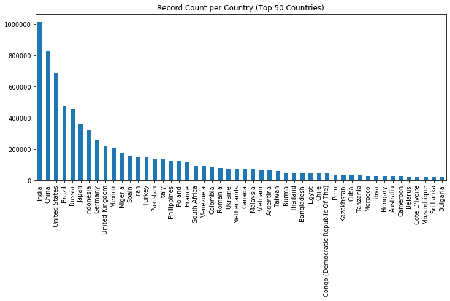

```python
RecordsPerCountry = df['Country'].value_counts()
RecordsPerCountry[:50].plot.bar(figsize=(12,5), title="Record Count per Country (Top 50 Countries)")
```

Well, looks like using single country data sets should work.

Now I need to understand more about the data. How the key variables are distrubuted, and how they vary at a consolidated view.

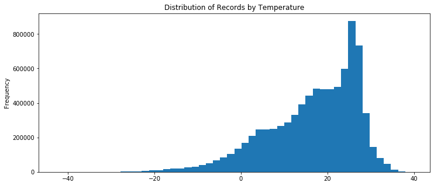

```python
df['AverageTemperature'].plot(kind='hist', bins=50, figsize=(12, 5), title="Distribution of Records by Temperature")
```

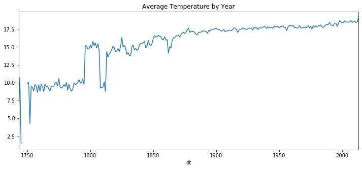

```python
MeanTempByYear = df.groupby(df['dt'].dt.year)['AverageTemperature'].mean()
MeanTempByYear.plot.line(figsize=(12,5), title="Average Temperature by Year")
```

Looking at the plot above I can see that there are likely to be some missing records. This also is demonstrated by the initial examination of the data above where NaN values can be found in the Average Tempoerature and Uncertainty fields.

```python
df.isna().sum()
```

```
dt                                    0
AverageTemperature               364130
AverageTemperatureUncertainty    364130
City                                  0
Country                               0
Latitude                              0
Longitude                             0
dtype: int64
```

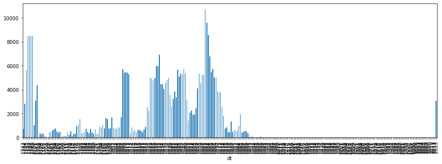

```python
MissingTempData = df.isna().groupby(df['dt'].dt.year)['AverageTemperature'].sum()
MissingTempData.plot.bar(figsize=(15,5))
```

Finally to get a better understanding of the data I want to ensure I am aware of outliers.

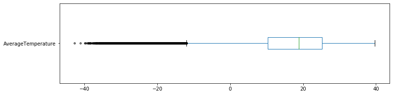

```python
df['AverageTemperature'].plot.box(vert=False, figsize=(12,3), sym='.')
```

```python
Q1, median, Q3 = df['AverageTemperature'].quantile(0.25), df['AverageTemperature'].quantile(0.5), df['AverageTemperature'].quantile(0.75)
IQR = Q3 - Q1

print('Temperature Quartiles: Q1 {}, Median {}, Q3 {}'.format(Q1, median, Q3))
print('Flier Thresholds: Min {}, Max {}'.format((Q1 - 1.5 * IQR), (Q3 + 1.5 * IQR)))
```

```
Temperature Quartiles: Q1 10.299, Median 18.831, Q3 25.21
Flier Thresholds: Min -12.067500000000003, Max 47.5765
```